# Lesson 3A: Data Frame

DS 01-101: In-Depth Introduction to Data Science (Spring 2026)

Author

Affiliation

Hung Tong

Rowan University

## Readings

From **R Coding Basics: An Introduction to the Basics of Coding in R** by Dr. Gaston Sanchez:

- [Data Frames](https://www.gastonsanchez.com/R-coding-basics/4-02-data-frames.html)

## Topics

- Data frame and matrix
- Creating a data frame
- Selecting elements in a data frame
- Adding, removing, and transforming a column

## Data Frame

- A **matrix** is a tabular data structure containing values of the same type.
- A **data frame** is a matrix-like data structure in which each column may have a different type.

```
#>   Age Height Weight Gender
#> 1  25    168     65 Female
#> 2  32    175     70   Male
#> 3  28    160     55 Female
#> 4  40    180     80   Male
```

- To create a data frame, we can combine multiple vectors using

```r
age <- c(25, 32, 28, 40)
hei <- c(168, 175, 160, 180)
wei <- c(65, 70, 55, 80)
gen <- c("Female", "Male", "Female", "Male")

data.frame(age, hei, wei, gen)
```

```
#>   age hei wei    gen
#> 1  25 168  65 Female
#> 2  32 175  70   Male
#> 3  28 160  55 Female
#> 4  40 180  80   Male
```

- It is possible to specify the column names.

```r
age <- c(25, 32, 28, 40)
hei <- c(168, 175, 160, 180)
wei <- c(65, 70, 55, 80)
gen <- c('Female', 'Male', 'Female', 'Male')

data.frame(Age = age, Height = hei, Weight = wei, Gender = gen)
```

```
#>   Age Height Weight Gender
#> 1  25    168     65 Female
#> 2  32    175     70   Male
#> 3  28    160     55 Female
#> 4  40    180     80   Male
```

- We can also type in the values directly.

```r
data.frame(
  Age    = c(25, 32, 28, 40),
  Height = c(168, 175, 160, 180),
  Weight = c(65, 70, 55, 80),
  Gender = c('Female', 'Male', 'Female', 'Male')
)
```

```
#>   Age Height Weight Gender
#> 1  25    168     65 Female
#> 2  32    175     70   Male
#> 3  28    160     55 Female
#> 4  40    180     80   Male
```

**Hands-On**

Create a data frame from the following data set

| Student | Score | Allergy |
| --- | --- | --- |
| Alice | 92 | peanut |
| Bob | 88 | none |
| Calvin | 95 | seafood |

**Answer:**

```r
### R code here
```

## Subsetting

### The dollar operator `$`

- A specific column (variable) can be quickly accessed using the dollar operator `$`
- Note that the output is a vector, not a data frame.

```r
df <- data.frame(
  Age    = c(25, 32, 28, 40),
  Height = c(168, 175, 160, 180),
  Weight = c(65, 70, 55, 80),
  Gender = c('Female', 'Male', 'Female', 'Male')
)

df$Height
```

```
#> [1] 168 175 160 180
```

**Hands-On**

Write R code to subset each individual column of `df`

```r
df <- data.frame(
  Age    = c(25, 32, 28, 40),
  Height = c(168, 175, 160, 180),
  Weight = c(65, 70, 55, 80),
  Gender = c('Female', 'Male', 'Female', 'Male')
)
```

**Answer:**

```r
### R code here
```

**Hands-On**

Try the following R code to see what it returns.

```r
df$Gender == 'Male'

df$Gender == 'Female'

df$Age < 30

df$Height[df$Gender == 'Male']

df$Height[df$Gender == 'Female']

df$Height[df$Age < 30]
```

**Answer:**

```r
### R code here
```

**Hands-On**

Write R code to find the following:

- Weights of all male individuals
- Ages of all female individuals
- Heights of those whose weights are at least 65

**Answer:**

```r
### R code here
```

### The brackets `[]`

- Certain elements of a matrix can be subset using the brackets `[]`

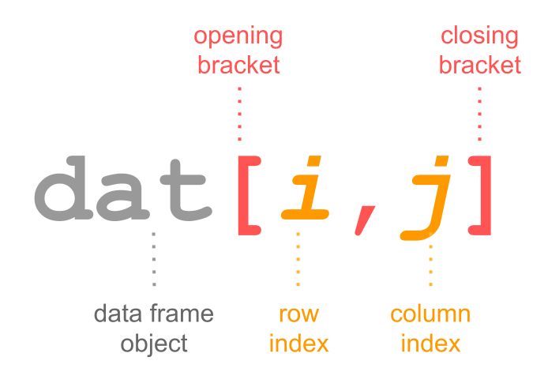

From Dr. Gaston Sanchez

**Hands-On**

Write R code to subset the indicated values of `df`

```r
df <- data.frame(
  Age    = c(25, 32, 28, 40),
  Height = c(168, 175, 160, 180),
  Weight = c(65, 70, 55, 80),
  Gender = c('Female', 'Male', 'Female', 'Male')
)

# row 1, column 3

# row 4, column 4

# row 3, column 2
```

**Answer:**

```r
### R code here
```

### Subsetting rows

- Subsetting rows can be done using numeric indexing with the brackets `[]`

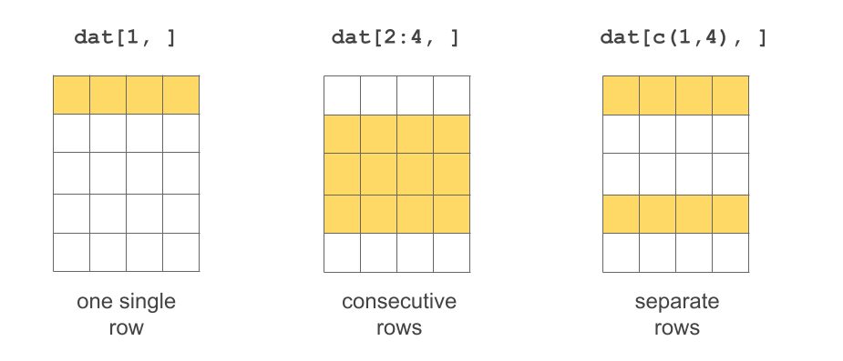

From Dr. Gaston Sanchez

```r
df <- data.frame(
  Age    = c(25, 32, 28, 40),
  Height = c(168, 175, 160, 180),
  Weight = c(65, 70, 55, 80),
  Gender = c('Female', 'Male', 'Female', 'Male')
)

# row 3

# rows 2 to 4 (2, 3, 4)

# rows 1, 2, and 4 only
```

**Answer:**

```r
### R code here
```

**Hands-On**

Try the following R code to see what it returns.

```r
df[df$Gender == 'Male', ]

df[df$Gender == 'Female', ]

df[df$Age < 30, ]
```

**Answer:**

```r
### R code here
```

**Hands-On**

Write R code to find the following all individuals who are:

- Older than 25
- Shorter than 170
- Heavier than 60

**Answer:**

```r
### R code here
```

### Subsetting columns

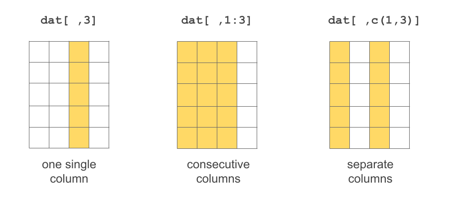

From Dr. Gaston Sanchez

**Hands-On**

Write R code to subset the indicated values of `df`

```r
df <- data.frame(
  Age    = c(25, 32, 28, 40),
  Height = c(168, 175, 160, 180),
  Weight = c(65, 70, 55, 80),
  Gender = c('Female', 'Male', 'Female', 'Male')
)

# column 1

# columns 1 to 3 (1, 2, 3)

# columns 1, 3, and 4 only
```

**Answer:**

```r
### R code here
```

- Another way to subset column(s) of a data frame is to use the brackets `[]` with column name(s). If more than one column name are given, the output is a data frame. Otherwise, the ouput is a vector.

```r
df <- data.frame(
  Age    = c(25, 32, 28, 40),
  Height = c(168, 175, 160, 180),
  Weight = c(65, 70, 55, 80),
  Gender = c('Female', 'Male', 'Female', 'Male')
)

df[, c('Age', 'Gender')]
```

```
#>   Age Gender
#> 1  25 Female
#> 2  32   Male
#> 3  28 Female
#> 4  40   Male
```

```r
df[, 'Height']
```

```
#> [1] 168 175 160 180
```

**Hands-On**

Write R code to subset the indicated column(s) of `df` using the brackets `[]`

```r
df <- data.frame(
  Age    = c(25, 32, 28, 40),
  Height = c(168, 175, 160, 180),
  Weight = c(65, 70, 55, 80),
  Gender = c('Female', 'Male', 'Female', 'Male')
)

# Height, Weight

# Gender, Weight, Age

# Gender

# Age
```

**Answer:**

```r
### R code here
```

## Adding a column

- Using the dollar operator `$` is the easiest way to add a column

```r
df <- data.frame(
  Age    = c(25, 32, 28, 40),
  Height = c(168, 175, 160, 180),
  Weight = c(65, 70, 55, 80),
  Gender = c('Female', 'Male', 'Female', 'Male')
)

df$Home <- c('Pitman', 'Glassboro', 'Clayton', 'Deptford')
```

```
#>   Age Height Weight Gender      Home
#> 1  25    168     65 Female    Pitman
#> 2  32    175     70   Male Glassboro
#> 3  28    160     55 Female   Clayton
#> 4  40    180     80   Male  Deptford
```

**Hands-On**

Create a new data frame as follows:

```r
df <- data.frame(
  Age    = c(25, 32, 28, 40),
  Height = c(168, 175, 160, 180),
  Weight = c(65, 70, 55, 80),
  Gender = c('Female', 'Male', 'Female', 'Male')
)
```

```
#>   Age Height Weight Gender      Home Married Savings
#> 1  25    168     65 Female    Pitman    TRUE   10000
#> 2  32    175     70   Male Glassboro    TRUE   25000
#> 3  28    160     55 Female   Clayton   FALSE    7000
#> 4  40    180     80   Male  Deptford    TRUE   40000
```

**Answer:**

```r
### R code here
```

## Removing a column

- Removing a column can be done with the dollar operator `$` as follows:

```r
df$Home <- NULL
```

**Hands-On**

Remove the column `Married` in `df`

**Answer:**

```r
### R code here
```

## Transforming a column

- The dollar operator `$` allows us to subset and transform a column.

```r
df$Savings <- df$Savings / 1000
```

```
#>   Age Height Weight Gender Savings
#> 1  25    168     65 Female      10
#> 2  32    175     70   Male      25
#> 3  28    160     55 Female       7
#> 4  40    180     80   Male      40
```

**Hands-On**

Convert `Weight` in kilograms to lbs

```r
df <- data.frame(
  Age    = c(25, 32, 28, 40),
  Height = c(168, 175, 160, 180),
  Weight = c(65, 70, 55, 80),
  Gender = c('Female', 'Male', 'Female', 'Male')
)
```

**Answer:**

```r
### R code here
```